# STAT 228: Mini Project 2

Zoe P Habel

2025-04-16

# Data Cleaning + Wrangling in R

## An example using Alone survivalists

Alone is a survival show which started in the US and has now expanded to Australia. The premise of the show is for several survival experts to try to outlast each other in the wilderness with limited survival supplies and in complete isolation. See the Wikipedia page for further details on the series.

Statistician Daniel Oehm created 4 excellent data sets containing various statistics from the TV series. More info about the data sets can be found on his [blog](https://gradientdescending.com/alone-r-package-datasets-from-the-survival-tv-series/) and on the [github repository](https://github.com/doehm/alone) containing the source code.

Data ‘cleaning’ and ‘wrangling’ refers to the process of preparing data for analysis. Basically, we want to make it easier to read and analyze ! Today we will be using the `survivalists` data set from the “alone” package to give a brief overview of the process.

### Exploring the data

Let’s start by loading our packages:

```r
library(tidyverse)
library(alone)
```

According to the package documentation, the `survivalist` package is *“a data frame of survivalists across all 9 seasons detailing name and demographics, location and profession, result, days lasted, reasons for tapping out (detailed and categorized), page URL.”*

**Let’s take a quick look!**

```r
head(survivalists)
```

[output not shown]

We won’t use every variable for our analysis, so here’s info on just a few:

**Pertinent Variable Descriptions:**

| Variable Name | Description |
| --- | --- |
| version | Country code for the version of the show |
| season | The season number |
| id | Survivalist ID |
| age | Age of survivalist |
| gender | Gender |
| result | Place the survivalist finished in the season |
| days_lasted | The number of days lasted in the game before tapping out or winning |
| medically_evacuated | Logical. If the survivalist was medically evacuated from the game |
| reason_category | A simplified category of the reason for tapping out |

### Tidying the data for our specific use

Since we’re not interested in analyzing every single variable, **let’s start by selecting the ones we want to keep using the function “select()”.**

```r
survivalist_data <- survivalists |>
  select(version,season,id,age,gender,result,days_lasted,medically_evacuated,reason_category)
head(survivalist_data)
```

[output not shown]

Let’s say we only want to look at the US seasons of the show since there’s more data. **We can use a function called “filter()” to filter by US seasons.**

```r
survivalists_US <- survivalist_data |>
  filter(version=="US") |>
  #we don't need the version column anymore, so we're removing it here
  select(!version)
```

The documentation explains that participants who have “NA” in certain categories relating to elimination are missing values because they were not eliminated, meaning that “NA” actually means “winner.” This is kind of confusing! But we can make this a bit clearer by adding a logical “winner” column. **We’ll use a function called “mutate()” to create a new column.**

```r
survivalists_US <- survivalists_US |>
  mutate(winner = if_else(result=="1"&is.na(reason_category),true ="YES",false = "NO"))
```

*Let’s check that our transformation worked by selecting all participants in first place & the lowest place*

```r
first_place <- survivalists_US|>
  slice_min(result)
table(first_place$winner)
#compare to the amount of "YES" winners in the whole set
table(survivalists_US$winner)
```

[output not shown]

There’s 12 “YES” among those in first place and the same amount in the whole data set – **looking good!**

### Ready to start analyzing !

Now that we’ve got a nice looking data set, let’s try to find some patterns!

First, make some plots which show us how many days participants lasted (`days_lasted`) by whether they won (`winner`) and and their final standing (`result`).

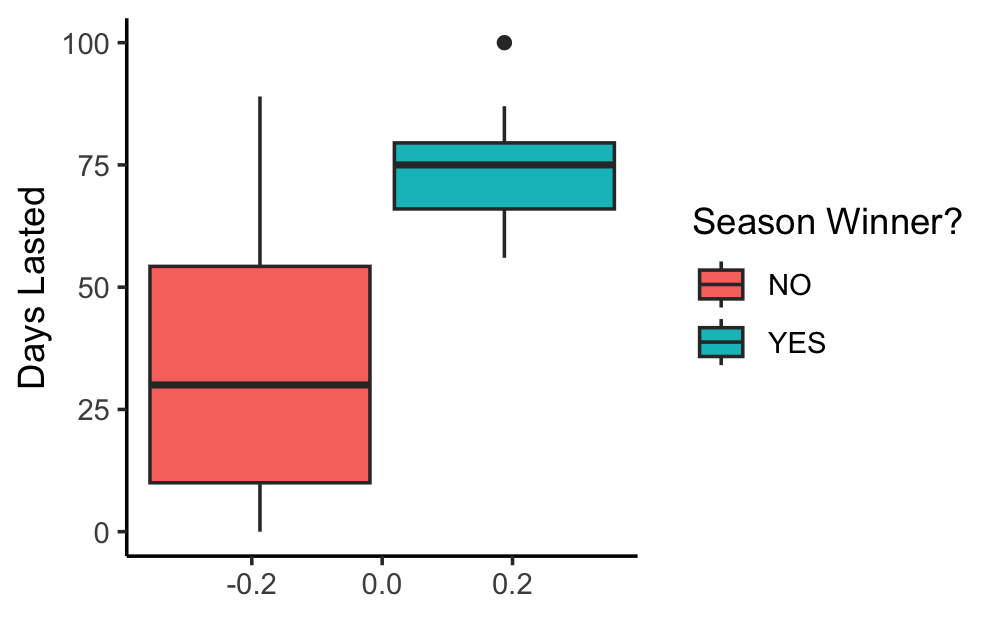

```r
ggplot(survivalists_US, aes(y=days_lasted, fill=winner)) +
  geom_boxplot() +
  labs(y="Days Lasted",fill="Season Winner?") +
  theme_classic()
```

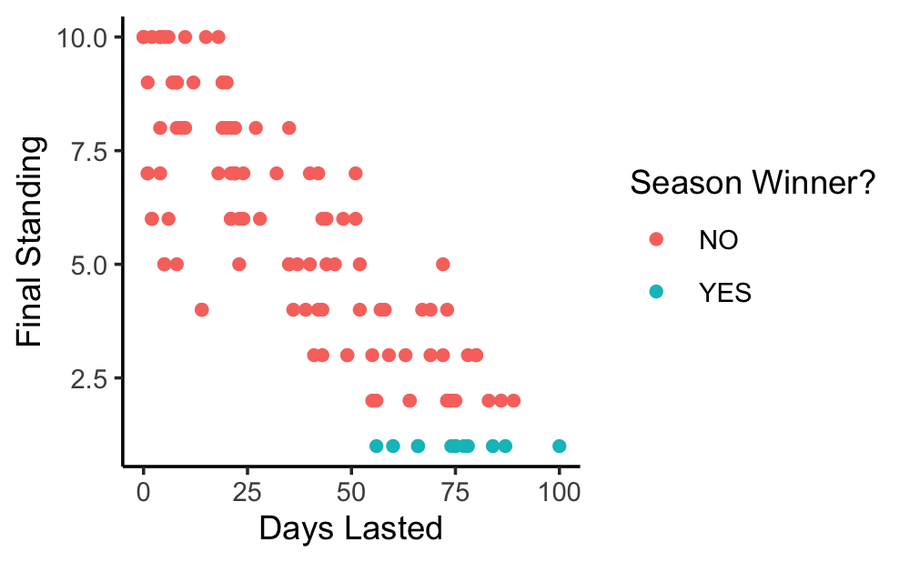

```r
ggplot(survivalists_US, aes(y=result, x=days_lasted,color=winner)) +
  geom_point() +
  labs(x="Days Lasted",y="Final Standing",color="Season Winner?") +
  theme_classic()
```

The boxplots show that every winner in this set lasted over 50 days, which is just under the third quartile # of days that those who did not win lasted. The scatter plot adds additional information about those outliers, showing that many of those participants who lasted longer made it further along in the competition!

There’s a lot more that could be explored, but we’ll leave it here for today! Thank you for following along with my tutorial, I hope you found this helpful!